# Final_report: analysis of the spam and ham messages

HyeonSeo (20221056)

2024/06/14

# Executive summary

Spam messages have become an issue nowadays. They always find a way into our message boxes and only do harm to people. As spam messages are getting more sophisticated and becoming more like real, normal messages (ham messages), there is a need to identify trends in spam messages that are distinct from other messages to stop further harm caused by them.

The main aim is to determine if there are any significant differences in the characteristics of spam messages and ham messages. If this analysis reveals significant differences between spam and ham messages, then recognizing spam messages would be easier. Consequently, the findings would be useful for people who seek to protect themselves from being deceived by spam messages.

I will primarily analyze the data through the scope of sentiment analysis. However, other basic analyses, such as frequency analysis, will also be conducted.

The main questions are the followings: - How do the frequency and usage patterns of words differ between spam and ham messages? - Do spam messages differ from ham messages in terms of the sentiment they appeal to? - What are the most common themes or topics identified in spam and ham messages?

The prediction is that since spam emails aim to deceive the reader and prompt them to take certain actions (for example, clicking a malicious link or leaking their own personal information), the messages would use more positive, gentle, and kind words.

After the analysis, the results did show some significant differences between the ham and spam message data. The TF-IDF frequency graph highlighted the 10 most used ‘core’ words in spam and ham messages. By examining the graph, it was possible to identify the core messages and main themes conveyed by each type of message. Spam messages were more focused on alluring readers with prizes, points, and gifts, whereas ham messages were more focused on daily conversations.

For sentiment analysis, the BING and NRC sentiment data sets were used. The BING analysis graph showed the negative and positive words used in both spam and ham messages. It was found that spam messages used more positive words than ham messages, which corresponded with the prediction. Additionally, it was evident that spam messages deliberately avoided using negative words.

Using the NRC sentiment data set showed which sentiment the messages evoked. Surprisingly, there were no significant differences between the sentiment that are conveyed the most by ham messages and those conveyed by spam messages.

Lastly, a bi-gram network was created to find out if there were any significant word combinations. Furthermore, having insight to these word combinations helped to find out the contexts of the messages. In the spam messages bi-gram network, word combinations such as ‘dont miss’, ‘bonus 2000’, ‘charge extra’, and ‘lucky day’ could be found. By looking at the result, it could be assumed that spam messages contain enticing phrases aimed at attracting the reader’s attention and prompting them to take action.

In contrast, the ham messages bi-gram network revealed combinations like ‘love ya’, ‘wife didn’t’, ‘stop bus’, and ‘babe hey’. These combinations suggest that ham messages are more focused on personal interactions and everyday communications.

This analysis highlights the distinct linguistic patterns in spam and ham messages, providing valuable insights to help people to detect spam messages. By understanding the common words, phrases and word pairings used in spam messages, it becomes easier to identify and filter them. Furthermore, it can be expected that these findings would contribute in development of an effective spam filtering algorithm, too.

The final advice would be if a message from unknown sender tells you that you can get something for free, or is willing to give you prize for no reason, then that message is highly likely to be a spam.

# Data background

# Data loading, cleaning and preprocessing

first, load spam.csv dataset into ‘full_data’ variable. you can check that v1 column tell us whether the message is ‘spam’ or ‘ham’, and v2 contains the actual text.

```r
# full_data = unprocessed data is saved
# v1 column = 'spam' 'ham' info is saved here
# v2 column = actual text is saved here

full_data <- read_csv("spam.csv", show_col_types = FALSE)
print(full_data)
```

```
## # A tibble: 5,572 × 5
##    v1    v2                                                    ...3  ...4  ...5
##    <chr> <chr>                                                 <chr> <chr> <chr>
##  1 ham   "Go until jurong point, crazy.. Available only in bu… <NA>  <NA>  <NA>
##  2 ham   "Ok lar... Joking wif u oni..."                       <NA>  <NA>  <NA>
##  3 spam  "Free entry in 2 a wkly comp to win FA Cup final tkt… <NA>  <NA>  <NA>
##  4 ham   "U dun say so early hor... U c already then say..."   <NA>  <NA>  <NA>
##  5 ham   "Nah I don't think he goes to usf, he lives around h… <NA>  <NA>  <NA>
##  6 spam  "FreeMsg Hey there darling it's been 3 week's now an… <NA>  <NA>  <NA>
##  7 ham   "Even my brother is not like to speak with me. They … <NA>  <NA>  <NA>
##  8 ham   "As per your request 'Melle Melle (Oru Minnaminungin… <NA>  <NA>  <NA>
##  9 spam  "WINNER!! As a valued network customer you have been… <NA>  <NA>  <NA>
## 10 spam  "Had your mobile 11 months or more? U R entitled to … <NA>  <NA>  <NA>
## # ℹ 5,562 more rows
```

Now, preprocess the data. Tokenize the text, and remove any stop words. Preprocessed data is stored in ‘data’ variable.

```r
# 'data' varaible = pre-processed full_data (tokenized, removed stop words)
# when tokenizing, the tokenized words are saved in 'word' column

data <- full_data %>%
  unnest_tokens(word, v2) %>%
  anti_join(stop_words, by = "word")

print(data)
```

```
## # A tibble: 38,221 × 5
##    v1    ...3  ...4  ...5  word
##    <chr> <chr> <chr> <chr> <chr>
##  1 ham   <NA>  <NA>  <NA>  jurong
##  2 ham   <NA>  <NA>  <NA>  crazy
##  3 ham   <NA>  <NA>  <NA>  bugis
##  4 ham   <NA>  <NA>  <NA>  world
##  5 ham   <NA>  <NA>  <NA>  la
##  6 ham   <NA>  <NA>  <NA>  buffet
##  7 ham   <NA>  <NA>  <NA>  cine
##  8 ham   <NA>  <NA>  <NA>  amore
##  9 ham   <NA>  <NA>  <NA>  wat
## 10 ham   <NA>  <NA>  <NA>  lar
## # ℹ 38,211 more rows
```

# Individual analysis and figures

## Anaysis and Figure 1

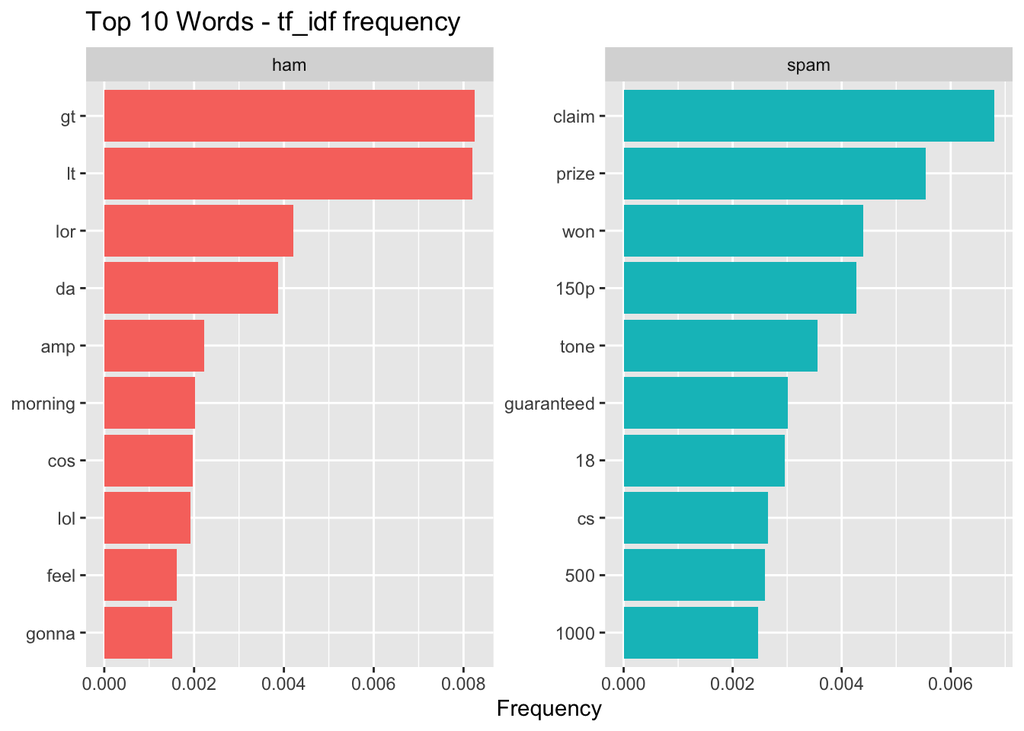

TF-IDF - top 10

```r
# processing data for TF-IDF analysis
# word_counts = word frequency counted
word_counts <- data %>%
  count(v1, word, sort = T)

# tf_counts = tf-idf processed data
tf_counts <- word_counts %>%
  bind_tf_idf(term = word,
              document = v1,
              n = n) %>%
  arrange(-tf_idf)

# counting the top 10 TF-IDF words for ham and spam
# top10 = top 10 tf-idf processed words
top10 <- tf_counts %>%
  group_by(v1) %>%
  slice_max(tf_idf, n = 10, with_ties = F)

top10$v1 <- factor(top10$v1,
                          levels = c("ham", "spam"))

# plotting bar graph:
ggplot(top10, aes(x = reorder_within(word, tf_idf, v1),
                  y = tf_idf,
                  fill = v1)) +
  geom_col(show.legend = F) +
  coord_flip() +
  facet_wrap(~ v1, scales = "free", ncol = 2) +
  labs(title = "Top 10 Words - tf_idf frequency",
       x = "Words",
       y = "Frequency") +
  scale_x_reordered() +
  labs(x = NULL)
```

With the preprocessed data variable ‘data’, a TF-IDF analysis was performed. The top ten most frequent words were selected and visualized in a bar graph. A bar graph is an excellent tool for visualizing frequency, as the length of each bar represents the repetition of the words in the texts.

TF-IDF analysis was conducted not only to find the most frequent words but also to identify the important and meaningful ones. Common frequency analysis, which merely counts the number of times each word appears in the data, does not account for the importance and significance of the words. Therefore, TF-IDF analysis was used to highlight words that are not just frequent but also carry substantial importance and meaning.

## Anaysis and Figure 2-1

```r
# seperate the ham and spam data
# data = pre-processed data (tokenized, removed stop_words)

# ham_data = only contains ham messages
ham_data <- data %>%
  filter(v1 == "ham")

# ham_data = only contains spam messages
spam_data <- data %>%
  filter(v1 == "spam")

# processing ham messages with BING:
sentiment_ham <- ham_data %>%
  inner_join(get_sentiments("bing")) %>%
  count(word, sentiment, sort = TRUE) %>%
  group_by(sentiment) %>%
  slice_max(order_by = n, n = 10, with_ties = FALSE) %>%
  ungroup()
# processing spam messages with BING:
sentiment_spam <- spam_data %>%
  inner_join(get_sentiments("bing")) %>%
  count(word, sentiment, sort = TRUE) %>%
  group_by(sentiment) %>%
  slice_max(order_by = n, n = 10, with_ties = FALSE) %>%
  ungroup()
sentiment_ham
```

```
## # A tibble: 20 × 3
##    word   sentiment     n
##    <chr>  <chr>     <int>
##  1 miss   negative     69
##  2 shit   negative     34
##  3 bad    negative     31
##  4 fuck   negative     28
##  5 pain   negative     25
##  6 missed negative     23
##  7 worry  negative     23
##  8 hurt   negative     22
##  9 sad    negative     21
## 10 lose   negative     20
## 11 love   positive    191
## 12 happy  positive    106
## 13 free   positive     60
## 14 nice   positive     58
## 15 fine   positive     50
## 16 smile  positive     45
## 17 cool   positive     40
## 18 ready  positive     35
## 19 sweet  positive     35
## 20 enjoy  positive     29
```

```r
sentiment_spam
```

```
## # A tibble: 20 × 3
##    word    sentiment     n
##    <chr>   <chr>     <int>
##  1 urgent  negative     63
##  2 miss    negative      7
##  3 crazy   negative      5
##  4 spook   negative      5
##  5 bored   negative      4
##  6 break   negative      4
##  7 cheap   negative      4
##  8 flirt   negative      4
##  9 refused negative      4
## 10 hard    negative      3
## 11 free    positive    223
## 12 prize   positive     92
## 13 won     positive     73
## 14 win     positive     60
## 15 awarded positive     38
## 16 award   positive     28
## 17 bonus   positive     21
## 18 top     positive     16
## 19 winner  positive     16
## 20 hot     positive     15
```

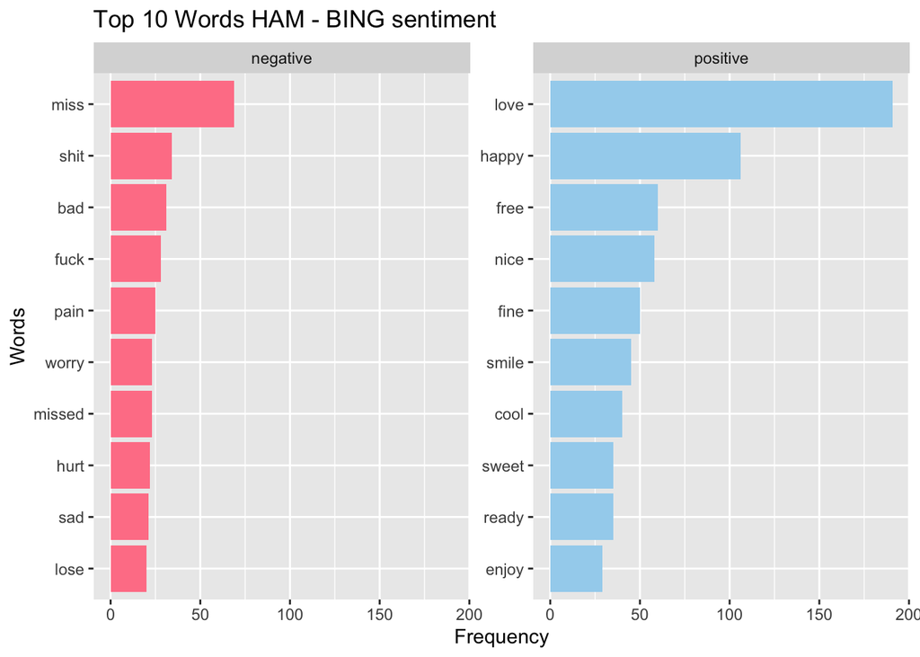

BING bar graph: HAM

```r
# plotting bar graph for HAM:
ggplot(sentiment_ham, aes(x = reorder(word, n), y = n, fill = sentiment)) +
  geom_bar(stat = "identity", show.legend = FALSE) +
  facet_wrap(~ sentiment, scales = "free_y") +
  labs(title = "Top 10 Words HAM - BING sentiment",
       x = "Words",
       y = "Frequency") +
  coord_flip() +
  scale_fill_manual(values = c("positive" = rgb(164, 211, 238, maxColorValue = 255),
                               "negative" = rgb(255, 130, 150, maxColorValue = 255)))
```

[figure not shown]

BING bar graph: SPAM

```r
# plotting bar graph for SPAM:
ggplot(sentiment_spam, aes(x = reorder(word, n), y = n, fill = sentiment)) +
  geom_bar(stat = "identity", show.legend = FALSE) +
  facet_wrap(~ sentiment, scales = "free_y") +
  labs(title = "Top 10 Words SPAM - BING sentiment",
       x = "Words",
       y = "Frequency") +
  coord_flip() +
  scale_fill_manual(values = c("positive" = rgb(164, 211, 238, maxColorValue = 255),
                               "negative" = rgb(255, 130, 150, maxColorValue = 255)))
```

Using the BING sentiment dataset allows us to highlight the positive and negative words used in both spam and ham messages. The slice_max() function was utilized to identify the top 10 most frequently used positive and negative words.

Once again, a bar graph was employed to effectively visualize the frequency. Upon examining the graph, both spam and ham messages did use more positive words then the negative words. However, spam messages notably used more positive words compared to ham messages.

An intriguing observation is that the most commonly used positive words in spam messages align closely with the findings from the earlier TF-IDF bar graph, which highlighted the most important and meaningful words.

## Anaysis and Figure 2-2

```r
# loading NRC sentiment data
# sentiment_list variable contains list of emotions that NRC work with.
load("nrc.rda")
sentiment_list <- unique(nrc$sentiment)

print(sentiment_list)
```

```
##  [1] "trust"        "fear"         "negative"     "sadness"      "anger"
##  [6] "surprise"     "positive"     "disgust"      "joy"          "anticipation"
```

```r
# checking which sentiment appeared most frequently in the words - HAM
sentiment_count_ham <- ham_data %>%
  inner_join(nrc) %>%
  count(sentiment, sort = TRUE)
# checking which sentiment appeared most frequently in the words - SPAM
sentiment_count_spam <- spam_data %>%
  inner_join(nrc) %>%
  count(sentiment, sort = TRUE)
```

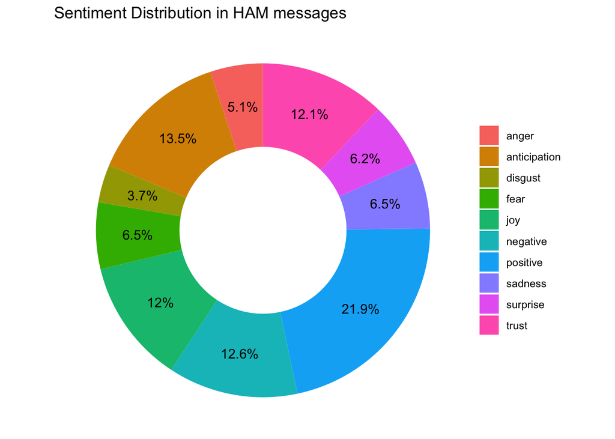

NRC donut graph: HAM

```r
# plotting donut chart - HAM
ggplot(sentiment_count_ham, aes(x = 2, y = n, fill = sentiment)) +
  geom_bar(stat = "identity", width = 1) +
  coord_polar(theta = "y") +
  geom_text(aes(label = paste0(round(n / sum(n) * 100, 1), "%")),
            position = position_stack(vjust = 0.5)) +
  labs(title = "Sentiment Distribution in HAM messages") +
  theme_void() +
  theme(legend.title = element_blank()) +
  xlim(0.5, 2.5)
```

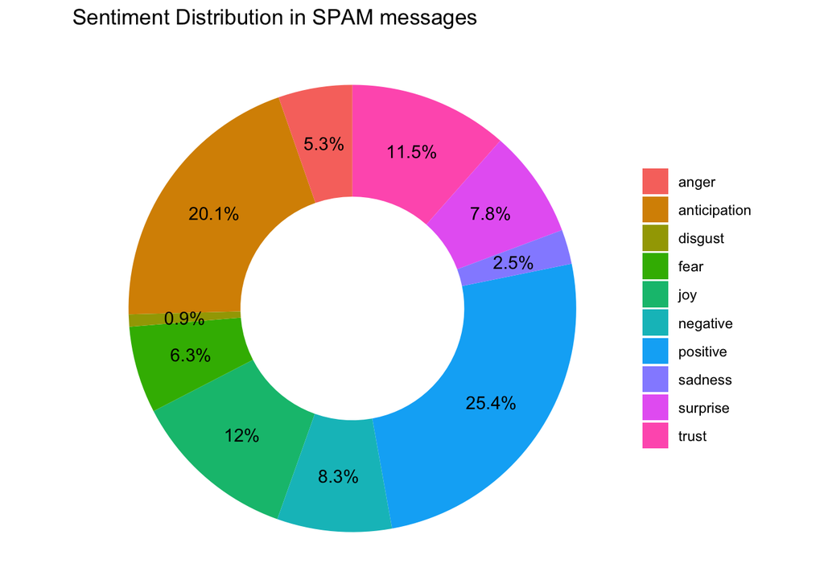

NRC donut graph: SPAM

```r
# plotting donut chart - SPAM
ggplot(sentiment_count_spam, aes(x = 2, y = n, fill = sentiment)) +
  geom_bar(stat = "identity", width = 1) +
  coord_polar(theta = "y") +
  geom_text(aes(label = paste0(round(n / sum(n) * 100, 1), "%")),
            position = position_stack(vjust = 0.5)) +
  labs(title = "Sentiment Distribution in SPAM messages") +
  theme_void() +
  theme(legend.title = element_blank()) +
  xlim(0.5, 2.5)
```

This time, a donut chart was plotted to clearly illustrate the proportion of sentiment words used in each set of messages.

## Anaysis and Figure 3

```r
# full_data variable was used because the tokenizing part needed to be done differently for bi-gram analysis.
# since data variable is already tokenized, we need to work with full_data here.

# processing data for bi-gram - SPAM
spam_data_bigram <- full_data %>%
  filter(v1 == "spam") %>%
  unnest_tokens(bigram, v2, token = "ngrams", n = 2) %>%
  filter(!is.na(bigram))

# in spam_data_seperated, the text column v2 is now seperated into word1, word2 column
spam_data_seperated <- spam_data_bigram %>%
  separate(bigram, c("word1", "word2"), sep = " ")

# removing stop word
spam_bigrams_filtered <- spam_data_seperated %>%
  filter(!word1 %in% stop_words$word) %>%
  filter(!word2 %in% stop_words$word)

spam_bigrams_counted <- spam_bigrams_filtered %>%
  count(word1, word2, sort = TRUE)

spam_bigrams_graph <- spam_bigrams_counted %>%
  filter(n > 4) %>%
  graph_from_data_frame()
```

```r
# processing data for bi-gram - HAM
ham_data_bigram <- full_data %>%
  filter(v1 == "ham") %>%
  unnest_tokens(bigram, v2, token = "ngrams", n = 2) %>%
  filter(!is.na(bigram))

# in ham_data_seperated, the text column v2 is now seperated into word1, word2 column
ham_data_seperated <- ham_data_bigram %>%
  separate(bigram, c("word1", "word2"), sep = " ")

# removing stop word
ham_bigrams_filtered <- ham_data_seperated %>%
  filter(!word1 %in% stop_words$word) %>%
  filter(!word2 %in% stop_words$word)

ham_bigrams_counted <- ham_bigrams_filtered %>%
  count(word1, word2, sort = TRUE)

ham_bigrams_graph <- ham_bigrams_counted %>%
  filter(n > 4) %>%
  graph_from_data_frame()
```

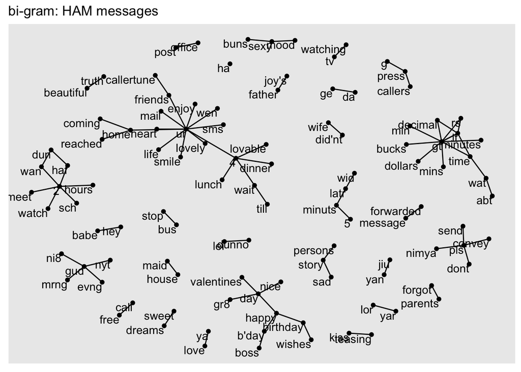

Bi-gram graph: HAM

```r
# plotting bigram graph - HAM:
set.seed(2023)

ggraph(ham_bigrams_graph, layout = "fr") +
  geom_edge_link() +
  geom_node_point() +
  geom_node_text(aes(label = name), vjust = 1, hjust = 1) +
  labs(title = "bi-gram: HAM messages")
```

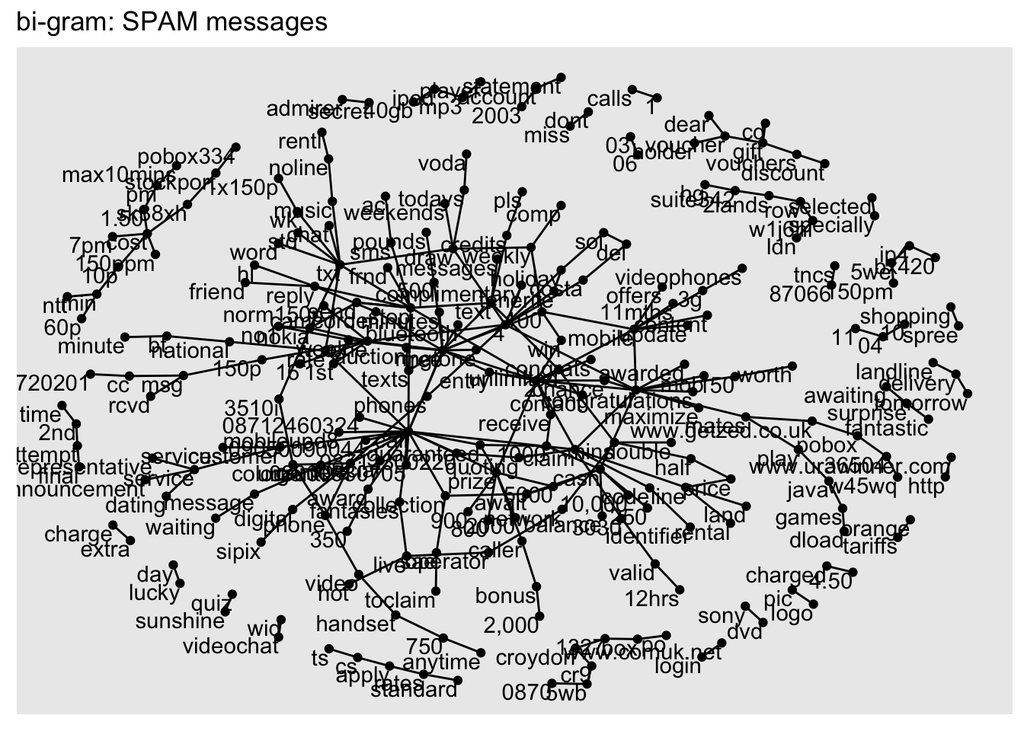

Bi-gram graph: SPAM

```r
# plotting bi-gram graph - SPAM:
set.seed(2023)

ggraph(spam_bigrams_graph, layout = "fr") +
  geom_edge_link() +
  geom_node_point() +
  geom_node_text(aes(label = name), vjust = 1, hjust = 1) +
  labs(title = "bi-gram: SPAM messages")
```

Bi-gram graphs were plotted for each dataset of spam and ham messages. Due to the relatively short length of SMS messages, bi-gram graphs was the one of the most effective method to handle the data.

By analyzing the plotted graph, it was able to find out the general context of the messages. Spam messages predominantly centered around topics like prize, getting free bonus, and extra. On the other hand, ham messages were more focused on daily conversations. Also, it was noticed that the words that were present in bi-gram graphs wre also present in the previous graphs (tf-idf graph, sentiment graphs, etc), too.

Consistent patterns across all graphs indicated several conclusions: A) There were significant differences in word usage between spam and ham messages. B) Spam messages tended to use more positive words compared to ham messages. C) These positive words frequently pertained to winning prizes.